# Visual Analysis of US Broadband Disparities

## Background

As online services and devices become increasingly ingrained and necessary in our lives in the modern world, the Internet infrastructure and service providers that connect our devices to these online services has become increasingly important as well. Americans depend on reliable and fast broadband internet to conduct their business everyday in the 21st century.

Yet, despite this necessity, millions of Americans have little to no access to broadband internet, most of them in rural areas where Internet Service Providers deem it unprofitable to provide broadband service (Fingas 2018). A lack of fast broadband Internet also means a lack of new business investment in the community, as most modern businesses require fast, reliable internet just to run, causing many rural communities to take things into their own hands (Kang 2017).

These issues are magnified by the gross inaccuracies often found on reports analyzing broadband connectivity, creating little motivation by policy makers to fix things (Lenz 2018). This, and other factors like unaffordable broadband prices, exacerbates inequality, by restricting opportunities for communication, education, and employment to those who need them most, like unemployed citizens (Fingas 2018).

## Data

| Name/Link | Rows | Vars | Unit |
| --- | --- | --- | --- |
| [NYS Broadband Availability](https://data.ny.gov/Economic-Development/Broadband-Availability-By-Municipality/sjc6-ftj4) | 1,635 | 24 | Municipality |
| [People Without Internet](https://www.kaggle.com/madaha/people-without-internet) | 821 | 23 | Municipality |
| [Urban Rate Broadband Survey](https://public.opendatasoft.com/explore/dataset/urban-rate-broadband-survey/table/) | 9,122 | 14 | ISP in Market |
| [American Community Survey 2017](https://www.census.gov/programs-surveys/acs/) | 3,108 | 36 | County |

## People Without Internet (American Community Survey 2016)

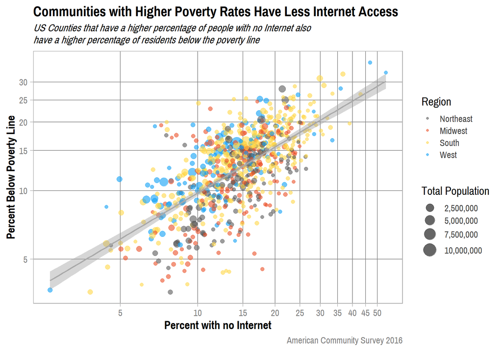

```r
ggplot(data = people_net, aes(x = percent_no_internet, y = percent_below_poverty)) +
  geom_point(aes(size = P_total, color = region), alpha = 0.6) +
  scale_color_manual(values = color_pal(4)) +
   scale_size(range = c(2, 8.5), labels = comma) +
  geom_smooth(method='lm',formula=y~x, color = "dark grey") +
  labs(title = "Communities with Higher Poverty Rates Have Less Internet Access",
       subtitle = "US Counties that have a higher percentage of people with no Internet also \nhave a higher percentage of residents below the poverty line",
       x = "Percent with no Internet",
       y = "Percent Below Poverty Line",
       caption="American Community Survey 2016",
       color = "Region", size = "Total Population") +
  scale_x_log10(breaks = c(0, 5, 10, 15, 20, 25, 30, 35, 40, 45, 50)) +
  scale_y_log10(breaks = c(0, 5, 10, 15, 20, 25, 30)) +
  theme_master() +
  theme(panel.grid.minor = element_blank())
```

As stated previously, there is evidence that a lack of Internet access can exacerbate inequality. While there is not enough evidence to make a causal relationship, the strong correlation between poverty and Internet access at least shows that a relationship does exist between the two. The lack of a clear trend between region or county population and this internet access - poverty relationship suggests that this relationship holds true across all of America.

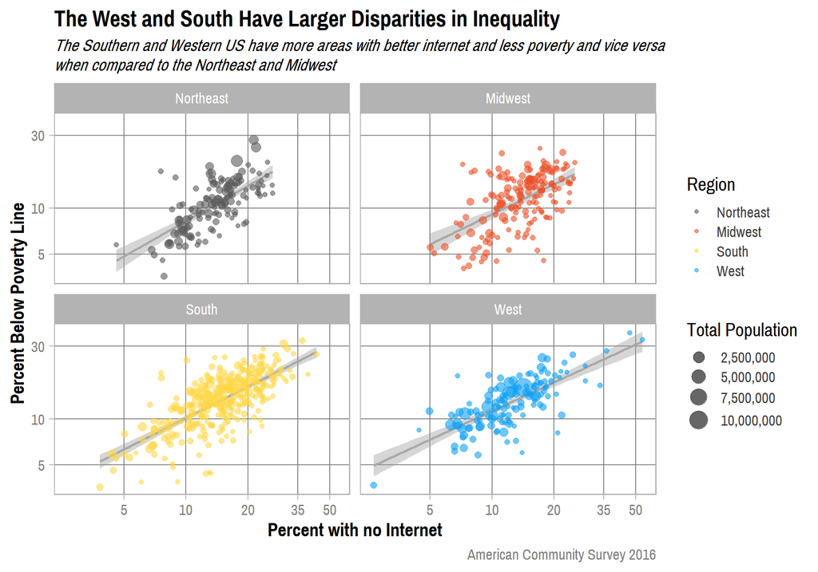

```r
ggplot(data = people_net, aes(x = percent_no_internet, y = percent_below_poverty)) +
  geom_smooth(method='lm',formula=y~x, color = "dark grey") +
  geom_point(aes(size = P_total, color = region), alpha = 0.6) +
  scale_color_manual(values = color_pal(4)) +
  scale_size(range = c(1.5, 7.5), labels = comma) +
  facet_wrap(~ region) +
  labs(title = "The West and South Have Larger Disparities in Inequality",
       subtitle = "The Southern and Western US have more areas with better internet and less poverty and vice versa \nwhen compared to the Northeast and Midwest",
       x = "Percent with no Internet",
       y = "Percent Below Poverty Line",
       caption="American Community Survey 2016",
       color = "Region", size = "Total Population") +
  scale_x_log10(breaks = c(0, 5, 10, 20, 35, 50)) +
  scale_y_log10(breaks = c(0, 5, 10, 30)) +
  theme_master()+
  theme(panel.grid.minor = element_blank())
```

However, despite the increased variance in the South and West, the relationship between Internet Access and Poverty holds true across the US. Perhaps the wider range of population density in the South and West exacerbates the disparity of this relationship. The extreme outlier in the lower left corner in Western America, is Douglas County, which is in the top 10 most populated counties in Colorado.

## Urban Broadband Survey

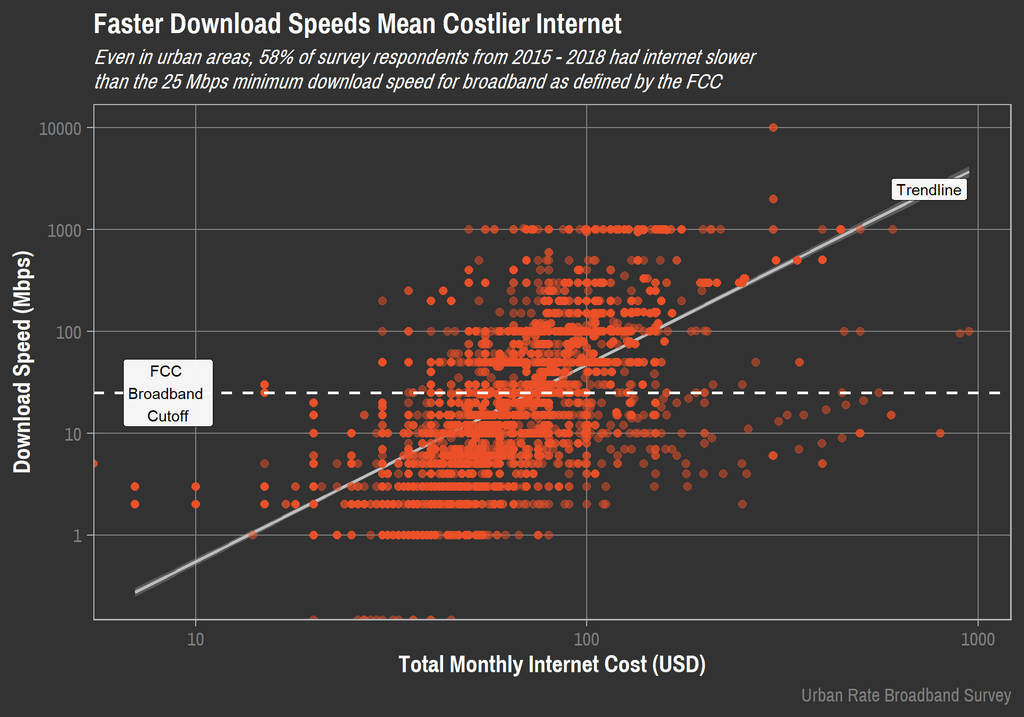

```r
chart_labels = tibble(text = c('FCC \nBroadband \nCutoff', 'Trendline'), x = c(8.5, 750), y = c(25, 2500))

ggplot(data = urban_bb, aes(x = `Total Charge`, y = `Download Bandwidth Mbps`)) +
  geom_smooth(method='lm', formula=y~x, color = "grey") +
  geom_point(color = color_pal(1), alpha = 0.5, size = 2.5) +
  geom_hline(yintercept = 25, linetype = 2, color = "white", size = 1) +
  geom_label(data = chart_labels, aes(x = x, y = y, label = text), alpha = 0.95) +
  scale_y_continuous(trans = "log10") +
  scale_x_continuous(trans = "log10") +
  labs(title = "Faster Download Speeds Mean Costlier Internet",
       subtitle = paste("Even in urban areas, ", round(perc_not_bb, 0), "% of survey respondents from 2015 - 2018 had internet slower \nthan the 25 Mbps minimum download speed for broadband as defined by the FCC", sep = ""),
       x = "Total Monthly Internet Cost (USD)",
       y = "Download Speed (Mbps)",
       caption = "Urban Rate Broadband Survey") +
  theme_master_dark() +
  theme(panel.grid.minor = element_blank())
```

Existing literature suggests that rural areas have disproportionately less broadband Internet access than urban areas. However, even in urban areas, Internet access can be extremely expensive, even for access that does not meet the FCC’s minimum bandwidth requirements to be legally considered broadband internet. While, for the most part, people can pay more to get faster speeds, inflated pricing disproportionately affects lower income families, who may become stuck with slow internet as it is all that they can afford.

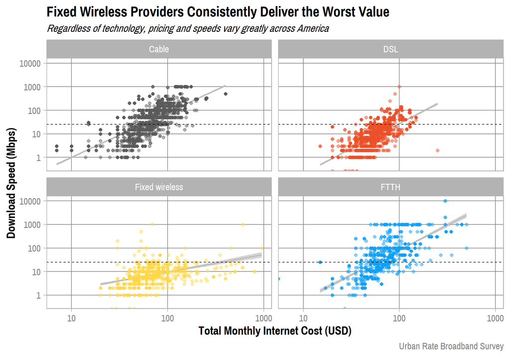

```r
ggplot(data = filter(urban_bb, Technology != "Other"), aes(x = `Total Charge`, y = `Download Bandwidth Mbps`)) +
  geom_smooth(method='lm', formula=y~x, color = "grey") +
  geom_point(aes(color = Technology), alpha = 0.5, size = 2) +
  scale_color_manual(values = color_pal(4)) +
  geom_hline(yintercept = 25, linetype = 2) +
  facet_wrap(~ Technology) +
  scale_y_continuous(trans = "log10") +
  scale_x_continuous(trans = "log10") +
  labs(title = "Fixed Wireless Providers Consistently Deliver the Worst Value",
       subtitle = "Regardless of technology, pricing and speeds vary greatly across America",
       x = "Total Monthly Internet Cost (USD)",
       y = "Download Speed (Mbps)",
       caption = "Urban Rate Broadband Survey") +
  theme_master() +
  hide_legend +
  theme(panel.grid.minor = element_blank())
```

Naturally, download speeds vary by the technology that Internet Service Providers use in their network. Fiber to the Home offers the highest speeds, followed by cable, however both have a similar price to speed ratio. DSL is typically much slower, but also less expensive, while Fixed Wireless is, overall, more expensive for the same speeds compared to other technologies.

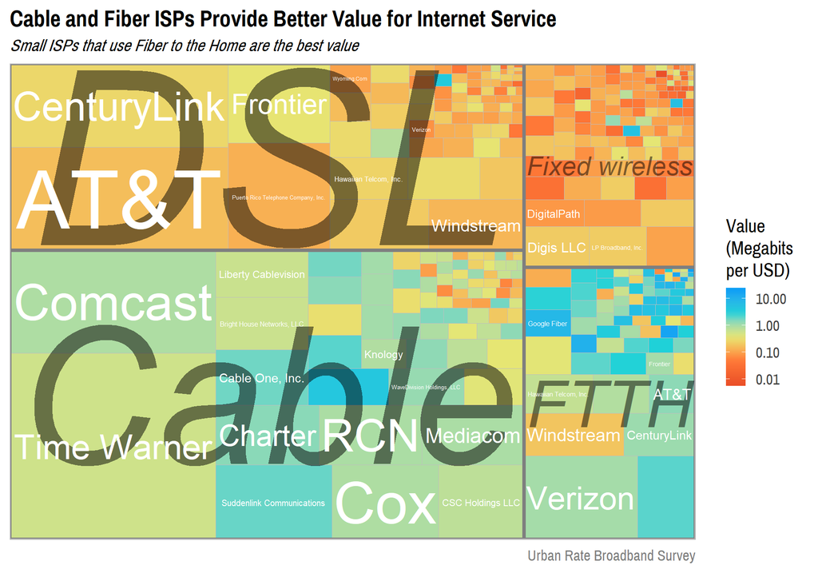

```r
ggplot(agg_urban_bb, aes(area = as.numeric(counts), fill = down_value, label = Group.1, subgroup = Technology)) +
  geom_treemap() +
  geom_treemap_subgroup_border() +
  geom_treemap_subgroup_text(place = "centre", grow = T, alpha = 0.5, colour =
                             "black", fontface = "italic", min.size = 0) +
  geom_treemap_text(colour = "white", place = "centre",
                    grow = TRUE) +
  scale_fill_gradientn(trans = "log10", colors = color_pal(5, type = "continuous")) +
  labs(title = "Cable and Fiber ISPs Provide Better Value for Internet Service",
       subtitle = "Small ISPs that use Fiber to the Home are the best value",
       fill = "Value \n(Megabits \nper USD)",
       caption = "Urban Rate Broadband Survey") +
  theme_master()
```

Overall, Fiber to the Home provides the best value for consumers, with cable not far behind. DSL and Fixed Wireless have the worst value on average. While small FTTH ISPs, like Google Fiber, typically provide better value than larger fiber ISPs, this is not true for other technologies, where larger ISPs usually provide better value.

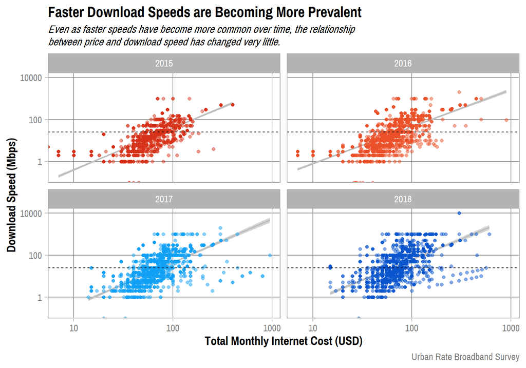

```r
ggplot(data = urban_bb, aes(x = `Total Charge`, y = `Download Bandwidth Mbps`)) +
  geom_smooth(method='lm', formula=y~x, color = "grey") +
  geom_point(aes(color = ordered(Year)), alpha = 0.5, size = 2) +
  scale_color_manual(values = color_pal(4, "continuous")) +
  geom_hline(yintercept = 25, linetype = 2) +
  facet_wrap(~ Year) +
  scale_y_continuous(trans = "log10") +
  scale_x_continuous(trans = "log10") +
  labs(title = "Faster Download Speeds are Becoming More Prevalent",
       subtitle = "Even as faster speeds have become more common over time, the relationship \nbetween price and download speed has changed very little.",
       x = "Total Monthly Internet Cost (USD)",
       y = "Download Speed (Mbps)",
       color = "Year",
       caption = "Urban Rate Broadband Survey") +
  theme_master() +
  hide_legend +
  theme(panel.grid.minor = element_blank())
```